# MATH9102-W5-Transformation

Author

Deirdre Lawless

```r
quiet_library <- function(pkg) {
  suppressMessages(suppressWarnings({
    if (!requireNamespace(pkg, quietly = TRUE)) {
      install.packages(pkg, quiet = TRUE)
    }
    library(pkg, character.only = TRUE)
  }))
}
quiet_library("tidyverse")  # Collection of R packages (dplyr, ggplot2, tidyr, etc.) for data wrangling, visualization, and analysis
quiet_library("pastecs")    # Tools for descriptive statistics, time series analysis, and data exploration (e.g., stat.desc)
quiet_library("FSA")        # Includes general tools for data analysis (e.g., nonparametric tests, bootstrapping)
quiet_library("semTools")   # Supplementary functions for Structural Equation Modeling (SEM), including model fit, reliability, and measurement invariance test
quiet_library("MASS")       # Includes function for Box-Cox transformation

#Amend this to reflect your folder structure
datalocation <- file.path("C:","Users", "deirdre.lawless", "datafiles")
datapath <- file.path(datalocation,'survey.dat')

#Read in the dataset
survey <- read.table(datapath)

#Setting the column names to be that used in the dataset but in lowercase to make life a bit easier
colnames(survey) <- tolower(colnames(survey))
```

This analysis is being conducted using data condensed from a postgraduate study conducted by Julie Pallant. The study was designed to explore the factors that impact on respondents’ psychological adjustment and wellbeing. The dataset is available at http://spss4.allenandunwin.com.s3-website-ap-southeast-2.amazonaws.com/data_files.html. The survey contained a variety of validated scales measuring constructs that the extensive literature on stress and coping suggest influence people’s experience of stress. The scales measured self-esteem, negative affect, perceptions of control, perceived stress, positive and negative affect, and life satisfaction. A scale was also included that measured people’s tendency to present themselves in a favourable or socially desirable manner. The survey was distributed to members of the general public in Melbourne, Australia and surrounding districts. This sample included 439 rows of data.

Total negative affect scores have a standardised skewness score of 7.58. Over 5% of the scores are outside of +/-2 using Curran, West and Finch’s guidelines. However 100% fall withing +/- 3.29. They can be treated as normal. But to illustrate the impact of transformation we will apply a log10 transformation

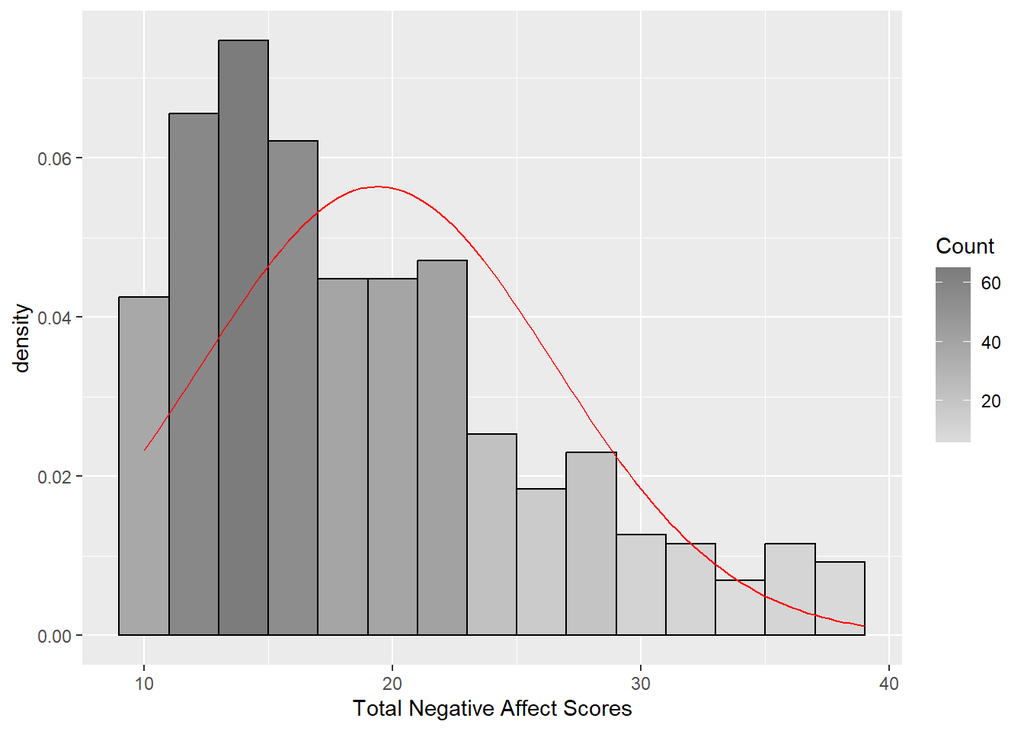

Figure 1: Histogram of Total Negative Affect Scores

```r
#Create a histogram
gg <- ggplot(survey, aes(x=tnegaff))
gg <- gg + labs(x="Total Negative Affect Scores")
gg <- gg + geom_histogram(binwidth=2, colour="black", aes(y=..density.., fill=..count..))
gg <- gg + scale_fill_gradient("Count", low="#DCDCDC", high="#7C7C7C")
gg <- gg + stat_function(fun=dnorm, color="red",args=list(mean=mean(survey$tnegaff, na.rm=TRUE), sd=sd(survey$tnegaff, na.rm=TRUE)))
gg
```

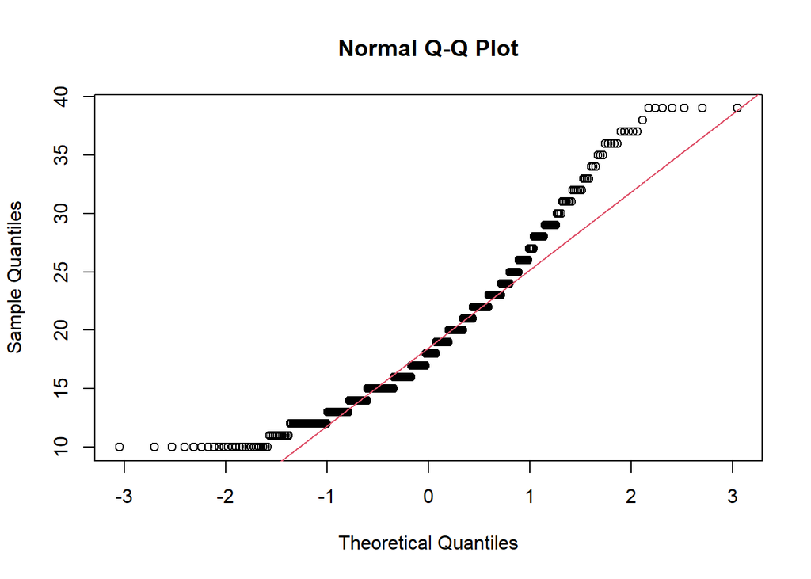

Figure 2: QQ Plot of Total Negative Affect Scores

```r
#Create a histogram
#Create a qqplot
qqnorm(survey$tnegaff)
qqline(survey$tnegaff, col=2) #show a line on the plot
```

```r
#stat.desc is a function from pastecs - make sure you include the basic switch=F to ensure you don't get scientific notation
pastecs::stat.desc(survey$tnegaff, basic=F)
```

```
      median         mean      SE.mean CI.mean.0.95          var      std.dev
  18.0000000   19.4045977    0.3390692    0.6664218   50.0110387    7.0718483
    coef.var
   0.3644419
```

```r
#Standardised scores for skew and kutosis
tpskew<-semTools::skew(survey$tnegaff)
tpkurt<-semTools::kurtosis(survey$tnegaff)
tpskew[1]/tpskew[2]
```

```
skew (g1)
 7.580495
```

```r
tpkurt[1]/tpkurt[2]
```

```
Excess Kur (g2)
        0.73867
```

```r
#Calculate percentage of standardized scores for total negative affect outside ranges
#+/- 1.96, +- 3.29
ztnegaff<- abs(scale(survey$tnegaff))

FSA::perc(as.numeric(ztnegaff), 1.96, "gt")
```

```
[1] 5.517241
```

```r
FSA::perc(as.numeric(ztnegaff), 3.29, "gt")
```

```
[1] 0
```

## Untransformed - using all our heuristics

Total negative affect scores data were assessed for normality. Visual inspection of the histogram and QQ-Plot (see Figure 1 and Figure 2) identified some issues with skewness and kurtosis. The standardized score for kurtosis (0.74) can be considered acceptable using the criteria proposed by West, Finch and Curran (1996), but the standardized score for skewness (7.58) was outside the acceptable range. However over 99% of standardized scores for total negative affect fall within the bounds of +/- 3.29, using the guidance of Field, Miles and Field (2013) the data can be considered to approximate a normal distribution (m=19.4, sd=7.07, n=435).

## Transforming data using log(10)

```r
# Transform the data and save as a column in the survey dataset
survey$lognaff <- log10(survey$tnegaff)
```

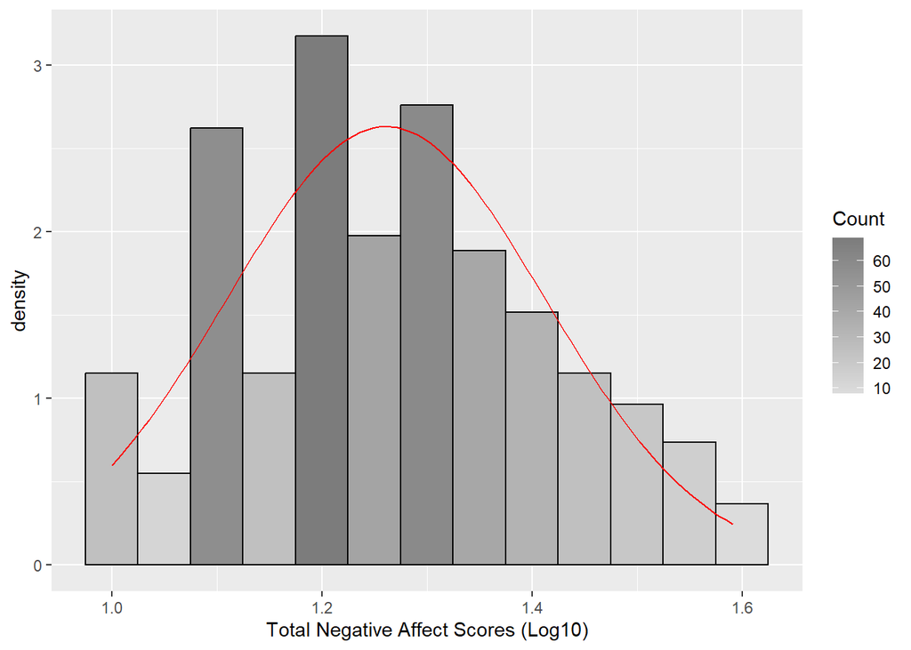

Figure 3: Histogram of Total Negative Affect Scores - Transformed using Log10

```r
#Create a histogram
gg <- ggplot(survey, aes(x=lognaff))
gg <- gg + labs(x="Total Negative Affect Scores (Log10)")
gg <- gg + geom_histogram(binwidth=.05, colour="black", aes(y=..density.., fill=..count..))
gg <- gg + scale_fill_gradient("Count", low="#DCDCDC", high="#7C7C7C")
gg <- gg + stat_function(fun=dnorm, color="red",args=list(mean=mean(survey$lognaff, na.rm=TRUE), sd=sd(survey$lognaff, na.rm=TRUE)))
gg
```

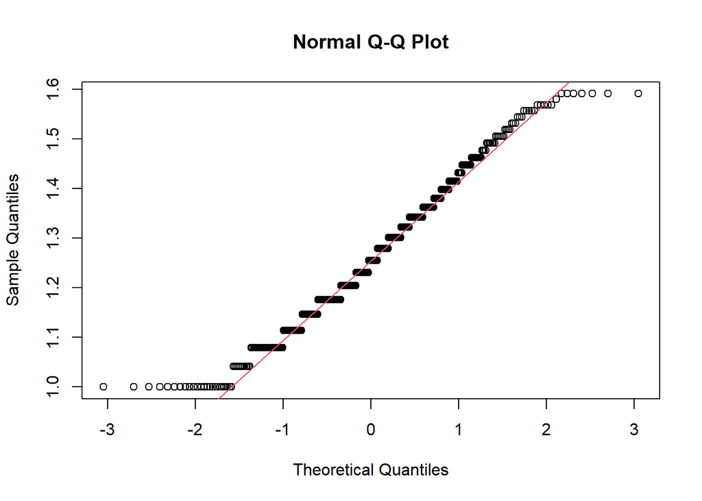

Figure 3: QQ Plot of Total Negative Affect Scores - Transformed using Log10

```r
#Create a histogram
#Create a qqplot
qqnorm(survey$lognaff)
qqline(survey$lognaff, col=2) #show a line on the plot
```

```r
#stat.desc is a function from pastecs - make sure you include the basic switch=F to ensure you don't get scientific notation
pastecs::stat.desc(survey$lognaff, basic=F)
```

```
      median         mean      SE.mean CI.mean.0.95          var      std.dev
 1.255272505  1.260981672  0.007271785  0.014292293  0.023002300  0.151665092
    coef.var
 0.120275414
```

```r
#Standardised scores for skew and kutosis
tpskew<-semTools::skew(survey$lognaff)
tpkurt<-semTools::kurtosis(survey$lognaff)
tpskew[1]/tpskew[2]
```

```
skew (g1)
 1.971078
```

```r
tpkurt[1]/tpkurt[2]
```

```
Excess Kur (g2)
      -3.010296
```

```r
#Calculate percentage of standardized scores for log10 total negative affect outside ranges
#+/- 1.96, +- 3.29
zlognegaff<- abs(scale(survey$lognaff))

FSA::perc(as.numeric(zlognegaff), 1.96, "gt")
```

```
[1] 2.988506
```

```r
FSA::perc(as.numeric(zlognegaff), 3.29, "gt")
```

```
[1] 0
```

Total negative affect scores data were transformed using logarithm base 10 transformation. These transformed scores were then assessed for normality. Visual inspection of the histogram and QQ-Plot (see Figure 3 and Figure 4) identified some issues with skewness and kurtosis. However, while the standardized score for skewness (1.97) can be considered acceptable using the criteria proposed by West, Finch and Curran (1996),the standardised score for kurtosis (-3.01) cannot. However as 95% of standardized scores for total negative affect fall within the bounds of +/- 1.96 and 100% fall within the bounds of +/- 3.29, using the guidance of Field, Miles and Field (2013) the transformed data can be considered to approximate a normal distribution (m=1.26, sd=0.15, n=435).

Note: All subsequent tests/models should use the transformed values not the raw.

## Transforming data using sqrt

```r
# Transform and store as a column in the survey dataset
survey$sqrtnaff <- sqrt(survey$tnegaff)
```

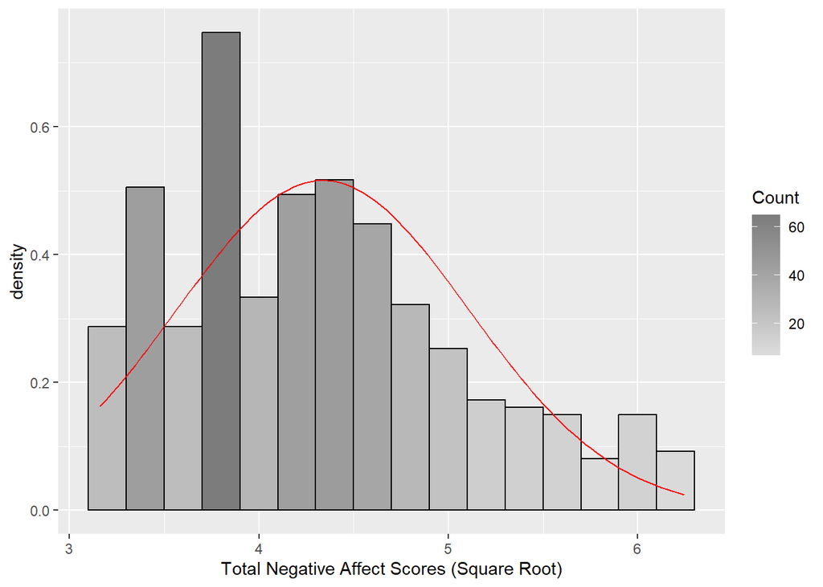

Figure 3: Histogram of Total Negative Affect Scores - Square Root Transformation

```r
#Create a histogram
gg <- ggplot(survey, aes(x=sqrtnaff))
gg <- gg + labs(x="Total Negative Affect Scores (Square Root)")
gg <- gg + geom_histogram(binwidth=.2, colour="black", aes(y=..density.., fill=..count..))
gg <- gg + scale_fill_gradient("Count", low="#DCDCDC", high="#7C7C7C")
gg <- gg + stat_function(fun=dnorm, color="red",args=list(mean=mean(survey$sqrtnaff, na.rm=TRUE), sd=sd(survey$sqrtnaff, na.rm=TRUE)))
gg
```

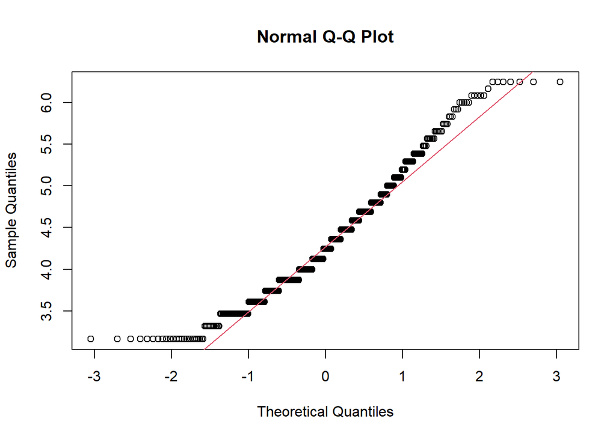

Figure 3: QQ Plot of Total Negative Affect Scores - Square Root Transformation

```r
#Create a histogram
#Create a qqplot
qqnorm(survey$sqrtnaff)
qqline(survey$sqrtnaff, col=2) #show a line on the plot
```

```r
#stat.desc is a function from pastecs - make sure you include the basic switch=F to ensure you don't get scientific notation
pastecs::stat.desc(survey$sqrtnaff, basic=F)
```

```
      median         mean      SE.mean CI.mean.0.95          var      std.dev
  4.24264069   4.33682912   0.03707356   0.07286605   0.59788535   0.77323046
    coef.var
  0.17829397
```

```r
#Standardised scores for skew and kutosis
tpskew<-semTools::skew(survey$sqrtnaff)
tpkurt<-semTools::kurtosis(survey$sqrtnaff)
tpskew[1]/tpskew[2]
```

```
skew (g1)
 4.758309
```

```r
tpkurt[1]/tpkurt[2]
```

```
Excess Kur (g2)
      -1.675562
```

```r
#Calculate percentage of standardized scores for square root total negative affect outside ranges
#+/- 1.96, +- 3.29
zsqrnegaff<- abs(scale(survey$sqrtnaff))

FSA::perc(as.numeric(zsqrnegaff), 1.96, "gt")
```

```
[1] 4.827586
```

```r
FSA::perc(as.numeric(zsqrnegaff), 3.29, "gt")
```

```
[1] 0
```

Total negative affect scores data were transformed using a square root transformation. These transformed scores were then assessed for normality. Visual inspection of the histogram and QQ-Plot (see Figure 3 and Figure 4) identified some issues with skewness and kurtosis. However, while the standardized score for kurtosis (-1.68) can be considered acceptable using the criteria proposed by West, Finch and Curran (1996),the standardised score for skewness (4.76) cannot. However as 95% of standardized scores for total negative affect fall within the bounds of +/- 1.96 and 100% fall within the bounds of +/- 3.29, using the guidance of Field, Miles and Field (2013) the transformed data can be considered to approximate a normal distribution (m=4.34, sd=0.77, n=435).

Note: All subsequent tests/models should use the transformed values not the raw.

## Transforming data using Box Cox transformation

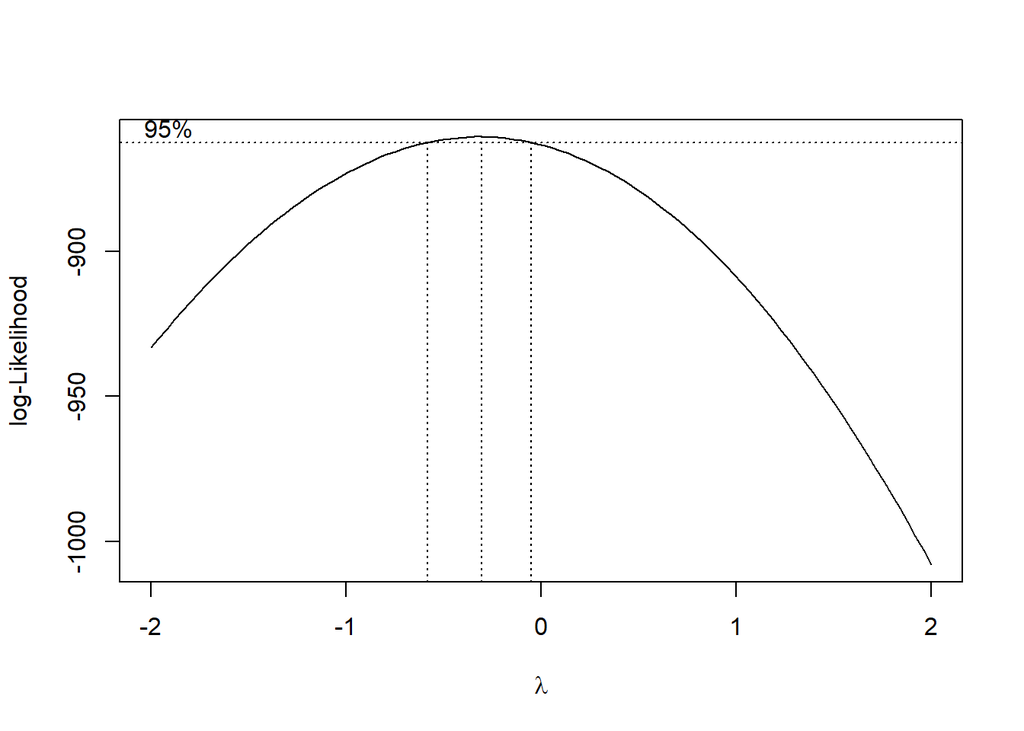

```r
# Transform and store as a column in the survey dataset

# Box–Cox transformation for tnegaff
bc <- MASS::boxcox(lm(tnegaff ~ 1, data = survey))   # inspect profile
```

```r
lambda <- bc$x[which.max(bc$y)]                # extract optimal lambda

# Apply the transformation
survey$bcnegaff <- if (abs(lambda) < 1e-6) {
  log(survey$tnegaff)
} else {
  (survey$tnegaff^lambda - 1) / lambda
}
```

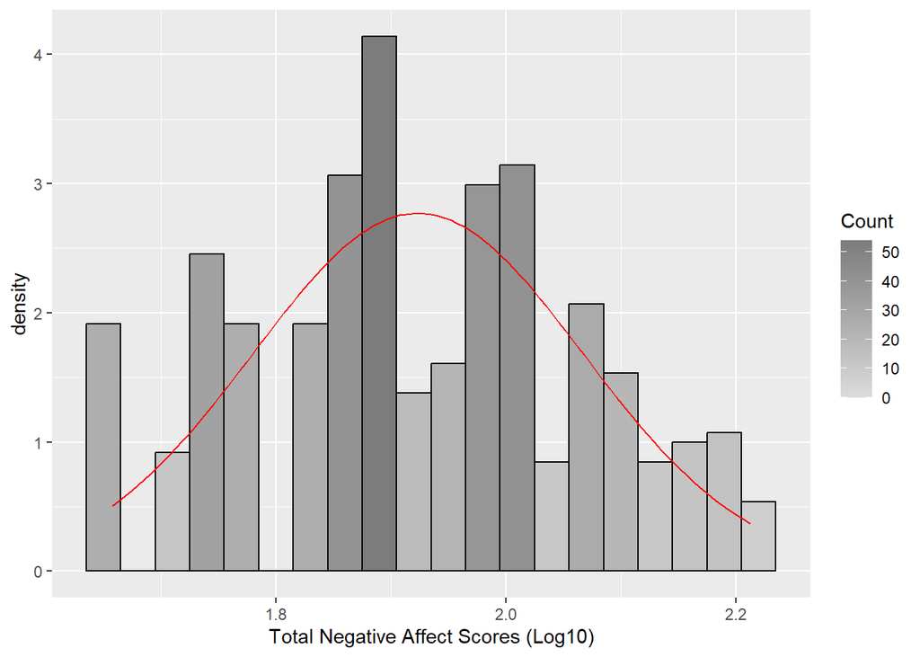

Figure 5: Histogram of Total Negative Affect Scores - Box-Cox Transformation

```r
#Create a histogram
gg <- ggplot(survey, aes(x=bcnegaff))
gg <- gg + labs(x="Total Negative Affect Scores (Log10)")
gg <- gg + geom_histogram(binwidth=.03, colour="black", aes(y=..density.., fill=..count..))
gg <- gg + scale_fill_gradient("Count", low="#DCDCDC", high="#7C7C7C")
gg <- gg + stat_function(fun=dnorm, color="red",args=list(mean=mean(survey$bcnegaff, na.rm=TRUE), sd=sd(survey$bcnegaff, na.rm=TRUE)))
gg
```

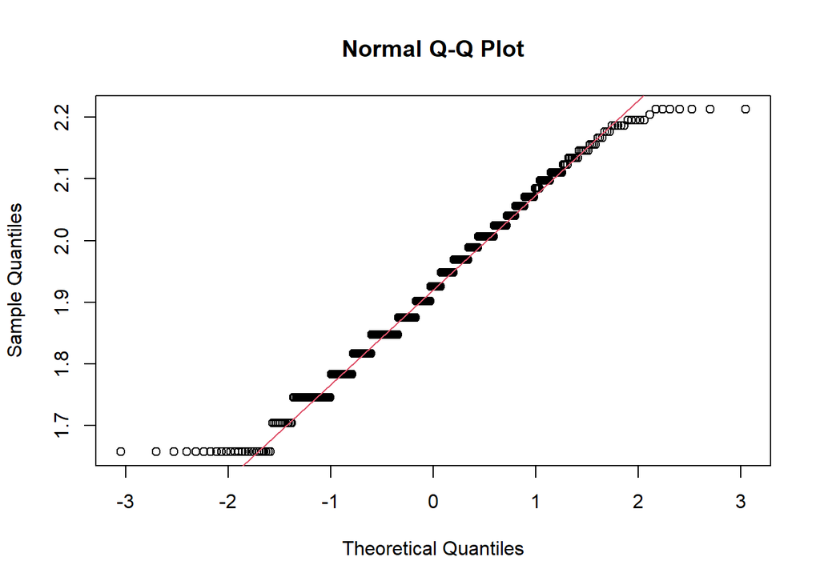

Figure 6: QQ Plot of Total Negative Affect Scores - Box-Cox Transformation

```r
#Create a histogram
#Create a qqplot
qqnorm(survey$bcnegaff)
qqline(survey$bcnegaff, col=2) #show a line on the plot
```

```r
#stat.desc is a function from pastecs - make sure you include the basic switch=F to ensure you don't get scientific notation
pastecs::stat.desc(survey$bcnegaff, basic=F)
```

```
      median         mean      SE.mean CI.mean.0.95          var      std.dev
 1.925551941  1.923414416  0.006902393  0.013566275  0.020724719  0.143960825
    coef.var
 0.074846494
```

```r
#Standardised scores for skew and kutosis
tpskew<-semTools::skew(survey$bcnegaff)
tpkurt<-semTools::kurtosis(survey$bcnegaff)
tpskew[1]/tpskew[2]
```

```
skew (g1)
0.3126125
```

```r
tpkurt[1]/tpkurt[2]
```

```
Excess Kur (g2)
      -3.301034
```

```r
#Calculate percentage of standardized scores for square root total negative affect outside ranges
#+/- 1.96, +- 3.29
zbcnegaff<- abs(scale(survey$bcnegaff))

FSA::perc(as.numeric(zbcnegaff), 1.96, "gt")
```

```
[1] 1.609195
```

```r
FSA::perc(as.numeric(zbcnegaff), 3.29, "gt")
```

```
[1] 0
```

Note: All subsequent tests/models should use the transformed values not the raw.